# Workplace mental health and psychosocial job characteristics

Feb 04, 2025

# Abstract

The mental health and wellbeing of various professions is an important predictor of economic outcomes, workforce retention as well as a broader indicator of our socioeconomic priorities. Recent changes and challenges to the nature of professional work in Australia, including shifting employee expectations, such as lockdowns and the rise of remote work due to the global COVID-19 pandemic, have highlighted the connection between psychosocial job characteristics and mental health. Here we describe the connection between mental health and job demands, job control and job security, and how it has changed in the past 20 years in Australia using annual nationally representative survey results from HILDA.

# Methods

## Variable definitions

### Professional codes

Professions were defined by the ISC 4-digit codes (i.e., `jbm688`) available in the restricted HILDA dataset, based on the Australian and New Zealand Standard Classification of Occupations ([ANZSCO 2006](https://www.abs.gov.au/ausstats/abs@.nsf/0/E3031B89999B4582CA2575DF002DA702?opendocument)).

### Remoteness

The Accessibility/Remoteness Index of Australia (ARIA+) is provided in HILDA (`hhsra`) and based on the Australian Statistical Geography Standard Remoteness Area framework (Summerfield et al., 2021). We defined the remoteness of the region of each teacher and collapsed the three most remote categories into a single category to produce three levels of remoteness: Major Cities, Inner Regional and Other (*Outer regional, remote and very remote*).

### Psychosocial characteristics of work

The psychosocial characteristics of work as defined by Butterworth, Strazdins, Rodgers, & Leach (2010), included three psychosocial job components (factors) from 12 items in all waves as well as an additional nine items available from Wave 5 (2005). We used all available items in each wave and constructed scores for each component by calculating the average of item responses (after reverse scoring the negatively worded items). Each component and the corresponding items are shown below. Item scores range from 1 to 7.

#### Job demands & complexity

| code | description | waves |
| --- | --- | --- |
| `jomms` | My job is more stressful than I had ever imagined | all waves |
| `jompi` | I fear that the amount of stress in my job will make me ill | all waves |
| `jomcd` | My job is complex and difficult | all waves |
| `jomns` | My job often required me to learn new skills | all waves |
| `jomus` | I use my skills in current job | all waves |
| `jomini` | My job requires me to take initiative | 5:20 |
| `jomfast` | I have to work fast in my job | 5:20 |
| `jomwi` | I have to work very intensely in my job | 5:20 |
| `jomtime` | I don’t have enough time to do everything in my job | 5:20 |

#### Job control

| code | description | waves |
| --- | --- | --- |
| `jomfd` | I have freedom to decide how I do my own work | all waves |
| `jomls` | I have a lot of say about what happens in my job | all waves |
| `jomfw` | I have freedom to decide when I do my work | all waves |
| `jomdw` | I have a lot of choice in deciding what I do at work | 5:20 |
| `jomflex` | My working times can be flexible | 5:20 |
| `jombrk` | I can decide when to take a break | 5:20 |
| `jomrpt` | My job requires me to do the same things over and over again | 5:20 |
| `jomvar` | My job provides me with a variety of interesting things to do | 5:20 |

#### Job security

| code | description | waves |
| --- | --- | --- |
| `jompf` | I get paid fairly for the things I do in my job | all waves |
| `jomsf` | I have a secure future in my job | all waves |
| `jomcsb` | Company I work for will still be in business in 5 years | all waves |
| `jomwf` | I worry about the future of my job | all waves |

# Check sample

```r
# Count by profession
occupations %>%
  count(year, profession) %>%
  spread(profession, n, fill = 0) %>%
  mutate(Total = rowSums(select(., -year)))
```

```
## # A tibble: 18 × 5
##     year Teachers Nurses Accountants Total
##    <dbl>    <dbl>  <dbl>       <dbl> <dbl>
##  1  2005      349    180         110   639
##  2  2006      336    203         114   653
##  3  2007      350    199         109   658
##  4  2008      332    192         112   636
##  5  2009      354    194         103   651
##  6  2010      350    186         100   636
##  7  2011      434    244         153   831
##  8  2012      403    235         148   786
##  9  2013      423    231         144   798
## 10  2014      393    259         141   793
## 11  2015      403    238         134   775
## 12  2016      389    252         131   772
## 13  2017      428    246         129   803
## 14  2018      426    255         139   820
## 15  2019      419    259         127   805
## 16  2020      406    274         128   808
## 17  2021      410    272         135   817
## 18  2022      413    270         114   797
```

```r
# Count by region
occupations %>%
  count(year, hhsra) %>%
  mutate(hhsra = fct_relevel(hhsra, "Major city")) %>%
  spread(hhsra, n, fill = 0) %>%
  mutate(Total = rowSums(select(., -year), na.rm=T))
```

```
## # A tibble: 18 × 7
##     year `Major city` `Inner regional` `Outer regional` Remote `Very remote` Total
##    <dbl>        <dbl>            <dbl>            <dbl>  <dbl>         <dbl> <dbl>
##  1  2005          433              144               56      3             3   639
##  2  2006          445              140               61      4             3   653
##  3  2007          433              154               60      9             2   658
##  4  2008          426              141               58      7             4   636
##  5  2009          433              142               62     10             4   651
##  6  2010          440              132               52      8             4   636
##  7  2011          582              160               73     12             4   831
##  8  2012          550              164               60      9             3   786
##  9  2013          564              168               57      8             1   798
## 10  2014          576              152               58      5             2   793
## 11  2015          546              155               62      6             6   775
## 12  2016          548              147               68      6             3   772
## 13  2017          561              152               79      8             3   803
## 14  2018          579              159               66     11             5   820
## 15  2019          561              162               70      8             4   805
## 16  2020          568              155               77      3             5   808
## 17  2021          560              164               81      7             5   817
## 18  2022          551              158               75      8             5   797
```

# Survey results

| Group | Characteristic | 20051 | 20221 | p-value2 |
| --- | --- | --- | --- | --- |
| Teachers | Total | N = 349 | N = 413 |  |
|  | Female | 253 (72%) | 293 (71%) | 0.6 |
|  | Age | 44 (35, 51) | 41 (32, 52) | 0.2 |
|  | Coupled | 260 (74%) | 319 (77%) | 0.4 |
|  | New parent | 50 (14%) | 79 (19%) | 0.078 |
|  | Edu |  |  | <0.001 |
|  | Postgraduate | 27 (7.7%) | 87 (21%) |  |
|  | Graduate diploma | 119 (34%) | 94 (23%) |  |
|  | Bachelors degree | 126 (36%) | 178 (43%) |  |
|  | Year 12 | 75 (21%) | 54 (13%) |  |
|  | Year 11 or below | 2 (0.6%) | 0 (0%) |  |
|  | Tenure (years) | 9 (3, 18) | 8 (3, 17) | 0.3 |
|  | Region |  |  | 0.10 |
|  | City | 225 (64%) | 279 (68%) |  |
|  | Regional | 91 (26%) | 83 (20%) |  |
|  | Remote | 33 (9.5%) | 51 (12%) |  |
|  | Real household income ($000s) | 61 (47, 73) | 76 (60, 97) | <0.001 |
|  | Mental health | 80 (68, 88) | 76 (64, 84) | <0.001 |
|  | Life satisfaction | 8.00 (7.00, 9.00) | 8.00 (8.00, 9.00) | 0.4 |
| Nurses | Total | N = 180 | N = 270 |  |
|  | Female | 165 (92%) | 244 (90%) | 0.6 |
|  | Age | 42 (35, 48) | 38 (29, 53) | 0.2 |
|  | Coupled | 132 (73%) | 192 (71%) | 0.6 |
|  | New parent | 35 (19%) | 43 (16%) | 0.3 |
|  | Edu |  |  | <0.001 |
|  | Postgraduate | 4 (2.2%) | 32 (12%) |  |
|  | Graduate diploma | 42 (23%) | 63 (23%) |  |
|  | Bachelors degree | 84 (47%) | 139 (51%) |  |
|  | Year 12 | 38 (21%) | 36 (13%) |  |
|  | Year 11 or below | 12 (6.7%) | 0 (0%) |  |
|  | Tenure (years) | 5 (2, 13) | 6 (2, 13) | 0.3 |
|  | Region |  |  | 0.8 |
|  | City | 115 (64%) | 180 (67%) |  |
|  | Regional | 42 (23%) | 60 (22%) |  |
|  | Remote | 23 (13%) | 30 (11%) |  |
|  | Real household income ($000s) | 58 (47, 72) | 79 (61, 96) | <0.001 |
|  | Mental health | 80 (68, 84) | 76 (64, 84) | 0.012 |
|  | Life satisfaction | 8.00 (7.00, 9.00) | 8.00 (7.00, 9.00) | 0.11 |
| Accountants | Total | N = 110 | N = 114 |  |
|  | Female | 40 (36%) | 61 (54%) | 0.010 |
|  | Age | 38 (29, 50) | 39 (32, 48) | 0.7 |
|  | Coupled | 83 (75%) | 93 (82%) | 0.3 |
|  | New parent | 15 (14%) | 24 (21%) | 0.14 |
|  | Edu |  |  | 0.003 |
|  | Postgraduate | 5 (4.5%) | 19 (17%) |  |
|  | Graduate diploma | 20 (18%) | 26 (23%) |  |
|  | Bachelors degree | 58 (53%) | 56 (49%) |  |
|  | Year 12 | 23 (21%) | 13 (11%) |  |
|  | Year 11 or below | 4 (3.6%) | 0 (0%) |  |
|  | Tenure (years) | 4 (1, 10) | 4 (2, 10) | 0.7 |
|  | Region |  |  | 0.7 |
|  | City | 93 (85%) | 92 (81%) |  |
|  | Regional | 11 (10%) | 15 (13%) |  |
|  | Remote | 6 (5.5%) | 7 (6.1%) |  |
|  | Real household income ($000s) | 68 (55, 89) | 81 (62, 106) | 0.005 |
|  | Mental health | 80 (68, 84) | 76 (68, 84) | 0.4 |
|  | Life satisfaction | 8.00 (7.00, 8.00) | 8.00 (7.00, 9.00) | 0.2 |

1N = N; n (%); Median (IQR)  
2Pearson's Chi-squared test; Wilcoxon rank sum test; Fisher's Exact Test for Count Data with simulated p-value (based on 2000 replicates)

## Mental health

Mental health was measured by the MHi-5 score (0-100) and compared to life-satisfaction responses (multiplied by 10 to match 0-100 range).

##### Figure 1. Mean ±SE mental health (dark) and life-satisfaction (light) by profession over time

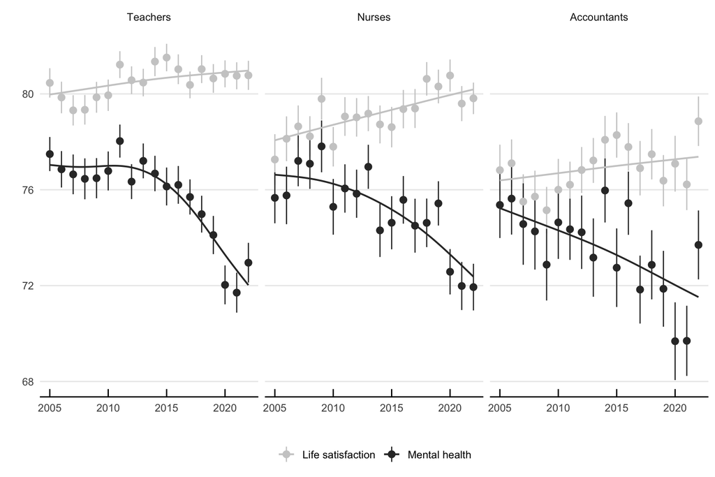

##### Figure 2. Mean ±SE mental health by region and profession over time

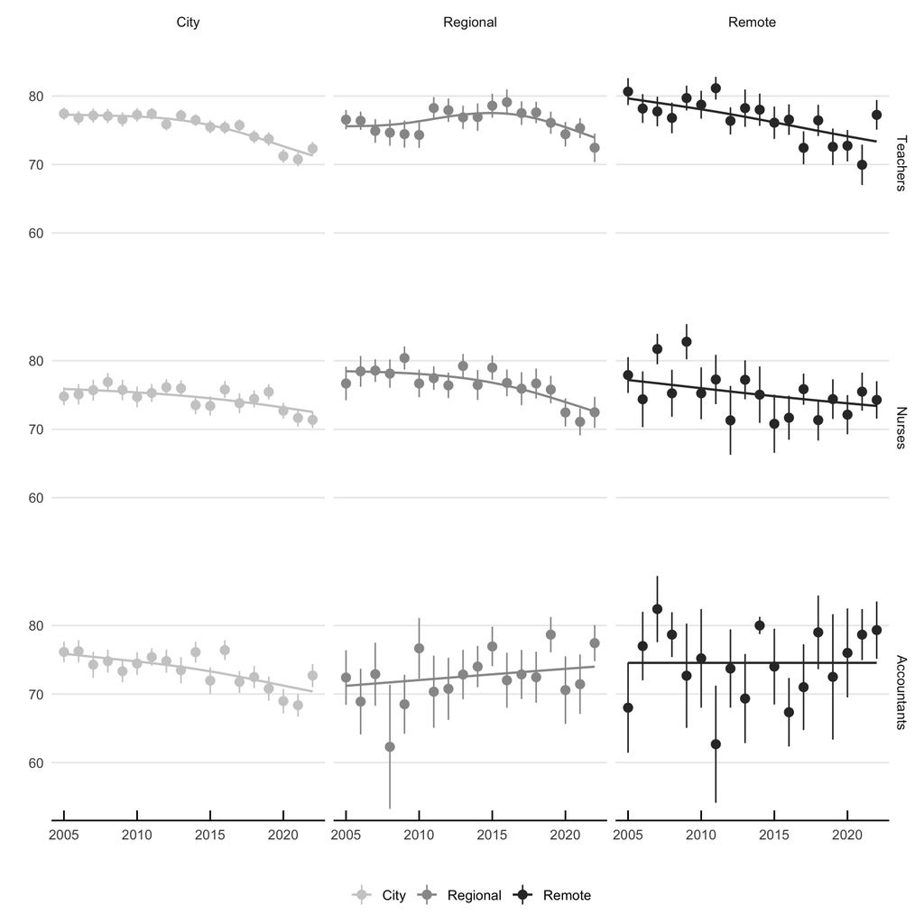

##### Figure 3. Mean ±SE mental health by school over time

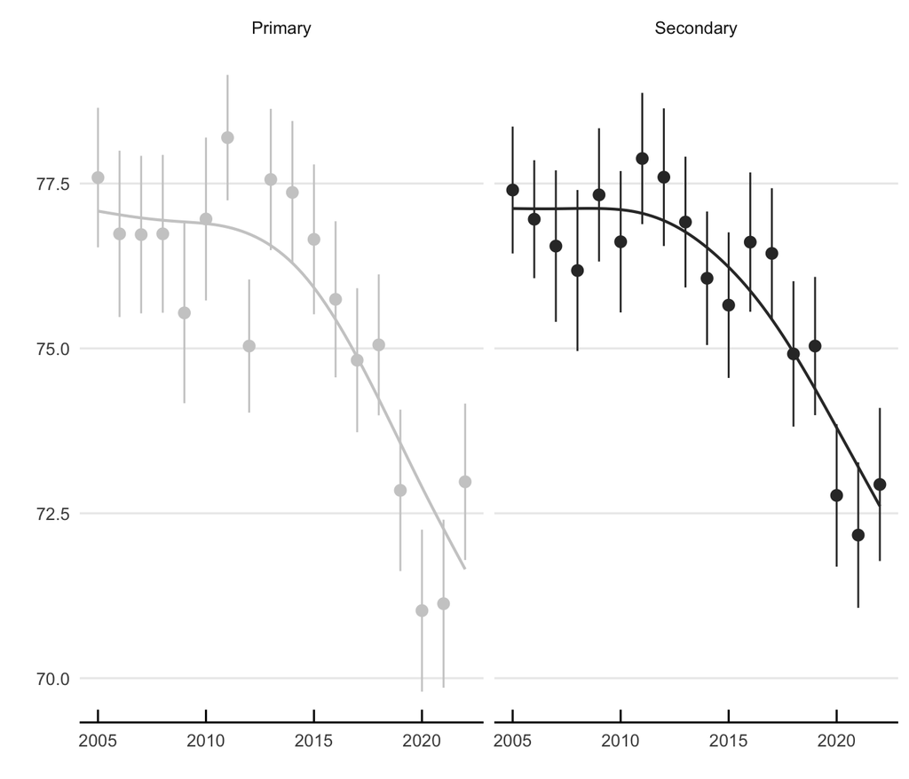

## Psychosocial characteristics of work

Job demands, job control and job security components were calculated from the averages of the items in each respective table (shown above).

##### Figure 4. Mean ±SE psychosocial job components by profession over time

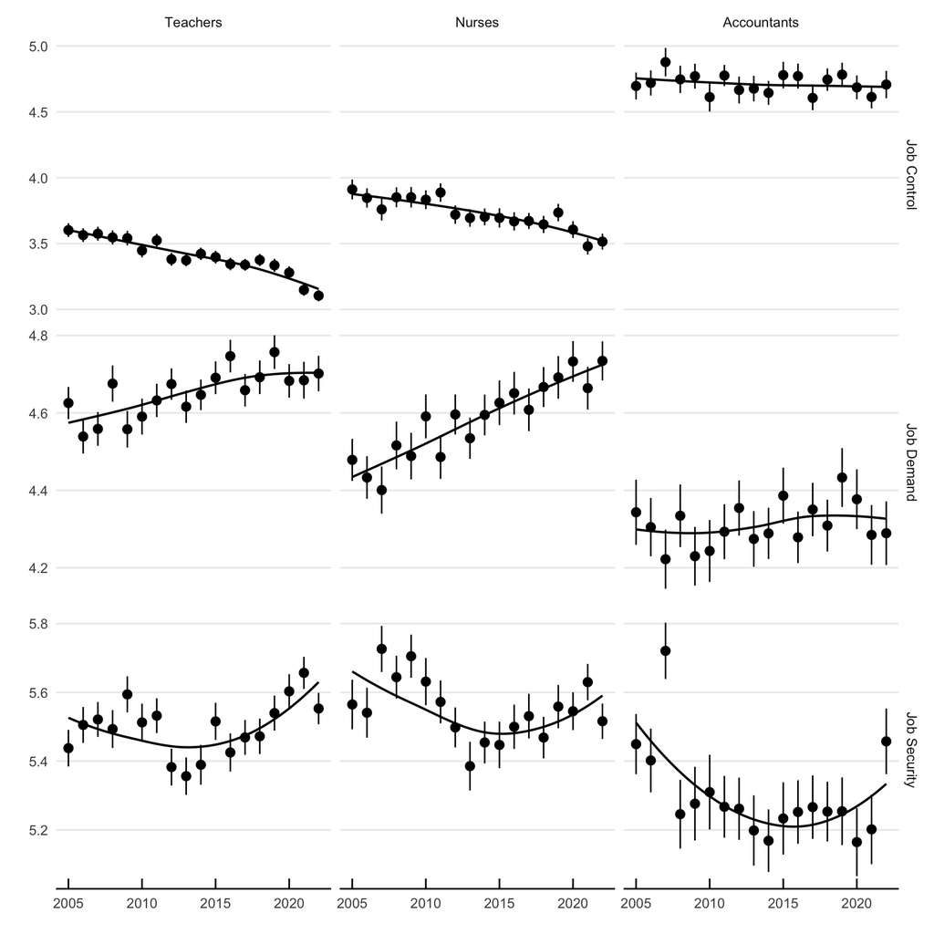

##### Figure 5. Mean ±SE psychosocial job components by school over time

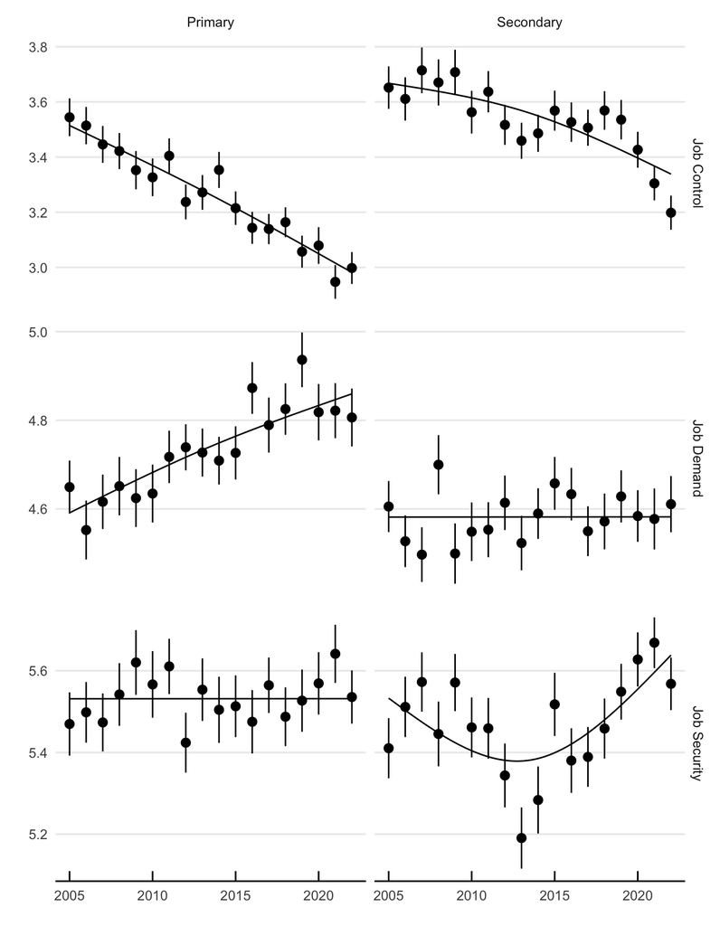

# References

Butterworth, P., Strazdins, L., Rodgers, B., & Leach, L. (2010). Deriving an evidence-based measure of job quality from the HILDA survey. *Australian Social Policy*, (9), 67–86.

Summerfield, M., Garrad, B., Hahn, M., Jin, Y., Kamath, R., Macalalad, N., et al.others. (2021). HILDA user manual–release 20. *Melbourne Institute of Applied Economic and Social Research, University of Melbourne*.